# Constructing a wealth index

By Stanley Nyoro

September 10, 2019

**Wealth index** is a social economics indicator for measuring living standard of households. It can also be used as a proxy for food access. According to [WFP](https://docs.wfp.org/api/documents/WFP-0000022418/download/), unlike poverty line, wealth index is not an absolute measure of poverty. When wealth of households is being referred to, it is only possible to talk of poor and wealthier households, but it is not possible to know who is absolutely poor or wealthy. The index is based on household’s ownership of selected assets, such as televisions and bicycles; materials used for housing construction; and types of water access and sanitation facilities. NB: When asset ownerships is skewed to one side, e.g. in urban areas more than in rural, it is advisable to build separate indices.  
Wealthy index is generated using principal component analysis, and place individuals on a continous scale- based on the scores of the first principal component. The scale is then ranked, after which it is subdivided into 5 equal stratums called wealth quintiles. I have come up with a wealth index using from a data I generated. In R, the first thing is to run required packages and then import the data.

```r
library(readxl)
library(tidyverse)
library(knitr)
library(kableExtra)
library(dplyr)
library(gmodels)
setwd("D:/My projects/Wealth index")

####Read multiple sheets
path<-"data.xlsx"

mydata2<- path %>%
        excel_sheets() %>%
        set_names() %>%
       map(read_excel,
           path = path)
```

```r
mydata2$codings %>%
  kable("html") %>%
  kable_styling(font_size=12) %>%
  kable_styling(bootstrap_options = c("striped", "hover", "condensed", "responsive"))
```

| Name of the Variable | Wealthier | Poorer |
| --- | --- | --- |
| Material of the house | 1 = concrete or wood | 0 = mud or thatch |
| Roof material | 1= tiles or galvanized iron or concrete | 0 = mud or thatch or plastic |
| Crowding | 1 = 5 or fewer people per room | 0 = 6 or more people per room |
| Type of lighting | 1 = electricity or gas | 0 = candle or wood |
| Source of water | 1 = piped into dwelling or borehole with pump or protected dug well | 0 = pond or unprotected well |
| Toilet facilities | 1 = flush or ventilated improved latrine | 0 = open pit or none (bush field) |
| Has a radio | 1 = yes | 0 = no |
| Has a TV | 1 = yes | 0 = no |
| Has a stove | 1 = yes | 0 = no |
| Has a fridge | 1 = yes | 0 = no |
| Has a mobile phone | 1 = yes | 0 = no |
| Has a bicycle | 1 = yes | 0 = no |
| Has a motorbike | 1 = yes | 0 = no |
| Has a car | 1 = yes | 0 = no |
| Has a bed | 1 = yes | 0 = no |
| Has a table | 1 = yes | 0 = no |
| Has a mattress | 1 = yes | 0 = no |
| Has a jembe/hoe | 1 = yes | 0 = no |
| Has sleeping mats | 1 = yes | 0 = no |
| Has machete | 1 = yes | 0 = no |
| Has mosquito net | 1 = yes | 0 = no |

The data has 595 individuals. We display information of the first 20 cases. After displaying, I will then run a principal component analysis using R.

```r
head(mydata2$data2,n=20)%>%
  kable("html") %>%
  kable_styling(font_size=9) %>%
  kable_styling(bootstrap_options = c("striped", "hover", "condensed", "responsive"))
```

| County | Car | Motorcycle | Bicycle | Radio | Television | Mobile phone | Computer | Refrigerator | Bed | Mattress | Machete / Slasher | Jembe / Hoe | Mosquito net | Table | Sleeping mats | Material of house | Roof material | Crowding | Type of lighting | Source of water | Toilet facility |
| --- | --- | --- | --- | --- | --- | --- | --- | --- | --- | --- | --- | --- | --- | --- | --- | --- | --- | --- | --- | --- | --- |
| County.A | 0 | 0 | 1 | 1 | 1 | 0 | 1 | 0 | 1 | 1 | 1 | 1 | 0 | 0 | 1 | 0 | 1 | 1 | 0 | 0 | 0 |
| County.B | 0 | 0 | 0 | 1 | 0 | 1 | 0 | 0 | 1 | 1 | 0 | 1 | 1 | 1 | 0 | 0 | 2 | 1 | 0 | 0 | 0 |
| County.B | 0 | 0 | 0 | 0 | 0 | 1 | 0 | 0 | 1 | 1 | 0 | 1 | 0 | 0 | 0 | 0 | 2 | 1 | 0 | 1 | 0 |
| County.A | 0 | 1 | 1 | 1 | 0 | 1 | 0 | 0 | 1 | 1 | 1 | 1 | 1 | 1 | 1 | 0 | 1 | 1 | 0 | 1 | 0 |
| County.B | 0 | 1 | 1 | 1 | 0 | 1 | 0 | 0 | 1 | 1 | 1 | 1 | 1 | 1 | 0 | 0 | 1 | 1 | 0 | 0 | 0 |
| County.A | 1 | 1 | 1 | 0 | 0 | 1 | 0 | 0 | 1 | 1 | 0 | 1 | 0 | 0 | 0 | 0 | 2 | 1 | 0 | 0 | 0 |
| County.A | 0 | 0 | 1 | 1 | 0 | 1 | 0 | 1 | 1 | 1 | 0 | 1 | 1 | 1 | 1 | 0 | 2 | 1 | 0 | 0 | 0 |
| County.A | 0 | 0 | 1 | 0 | 1 | 0 | 0 | 0 | 1 | 1 | 1 | 1 | 1 | 1 | 0 | 0 | 2 | 1 | 0 | 0 | 0 |
| County.A | 0 | 1 | 1 | 1 | 0 | 0 | 0 | 0 | 1 | 1 | 1 | 1 | 1 | 1 | 0 | 0 | 1 | 1 | 0 | 0 | 0 |
| County.A | 0 | 1 | 1 | 1 | 0 | 0 | 0 | 0 | 1 | 1 | 1 | 1 | 1 | 1 | 0 | 0 | 1 | 1 | 0 | 0 | 0 |
| County.B | 0 | 1 | 1 | 1 | 0 | 1 | 0 | 0 | 1 | 1 | 0 | 1 | 1 | 0 | 0 | 0 | 1 | 1 | 0 | 1 | 0 |
| County.A | 0 | 0 | 1 | 0 | 0 | 0 | 0 | 0 | 1 | 1 | 0 | 1 | 1 | 1 | 0 | 0 | 1 | 1 | 0 | 0 | 0 |
| County.A | 0 | 0 | 1 | 1 | 0 | 1 | 0 | 1 | 1 | 1 | 0 | 1 | 0 | 0 | 0 | 0 | 2 | 1 | 0 | 0 | 0 |
| County.A | 0 | 1 | 1 | 1 | 0 | 1 | 0 | 0 | 1 | 1 | 0 | 1 | 1 | 1 | 1 | 0 | 2 | 1 | 0 | 0 | 0 |
| County.B | 0 | 1 | 1 | 1 | 0 | 1 | 0 | 0 | 1 | 1 | 0 | 1 | 1 | 1 | 1 | 0 | 2 | 1 | 0 | 1 | 0 |
| County.B | 0 | 0 | 0 | 0 | 0 | 0 | 1 | 0 | 1 | 0 | 1 | 1 | 1 | 1 | 1 | 0 | 1 | 1 | 0 | 1 | 0 |
| County.A | 1 | 0 | 1 | 0 | 0 | 1 | 0 | 0 | 1 | 1 | 0 | 1 | 1 | 1 | 0 | 0 | 1 | 1 | 0 | 0 | 0 |
| County.A | 0 | 0 | 1 | 0 | 1 | 1 | 0 | 0 | 1 | 1 | 0 | 1 | 0 | 0 | 0 | 0 | 1 | 1 | 0 | 0 | 0 |
| County.B | 0 | 0 | 1 | 1 | 0 | 1 | 0 | 0 | 1 | 1 | 1 | 1 | 1 | 1 | 1 | 0 | 1 | 1 | 0 | 0 | 0 |
| County.A | 0 | 0 | 1 | 0 | 0 | 1 | 0 | 0 | 1 | 1 | 0 | 1 | 1 | 0 | 0 | 0 | 1 | 1 | 0 | 0 | 0 |

I then run a principal component analysis using the code below. PCA involves replacing many correlated variables with a set of principal uncorrelated ‘principal components’ which can explain much of the variance and represent unobserved characteristics of the population. The technique is based on decomposition of variance covariance matrix or correlation matrix.  
If variables used have different measurements e.g.in your data you have income measured in monetary terms, units measured in kgs, categorical scales, etc, you need first to standardize your variables.  
I have used the variance covariance matrix decomposition, and rotated factor loadings using varimax.The scores of the first principal component have been used to come with the index. First principal component explains the largest proportion of the total variance and it is used as the wealth index to represent the households wealth.

```r
library(psych)
prn<-psych::principal(mydata2$data2[,2:21], rotate="varimax", nfactors=3,covar=T, scores=TRUE)
index=prn$scores[,1]
```

```r
nlab<-c(1,2,3,4,5)
newdata<-mutate(mydata2$data2,quintile=as.factor(cut(index,breaks=5,labels=nlab)))
```

After creating a wealth index quintiles, we can cross tabulate with other variables such as region or residence status. Based on on the graph below on wealth breakdown in County A & County B, there are more people in County B that falls in the first stratum than in County A.

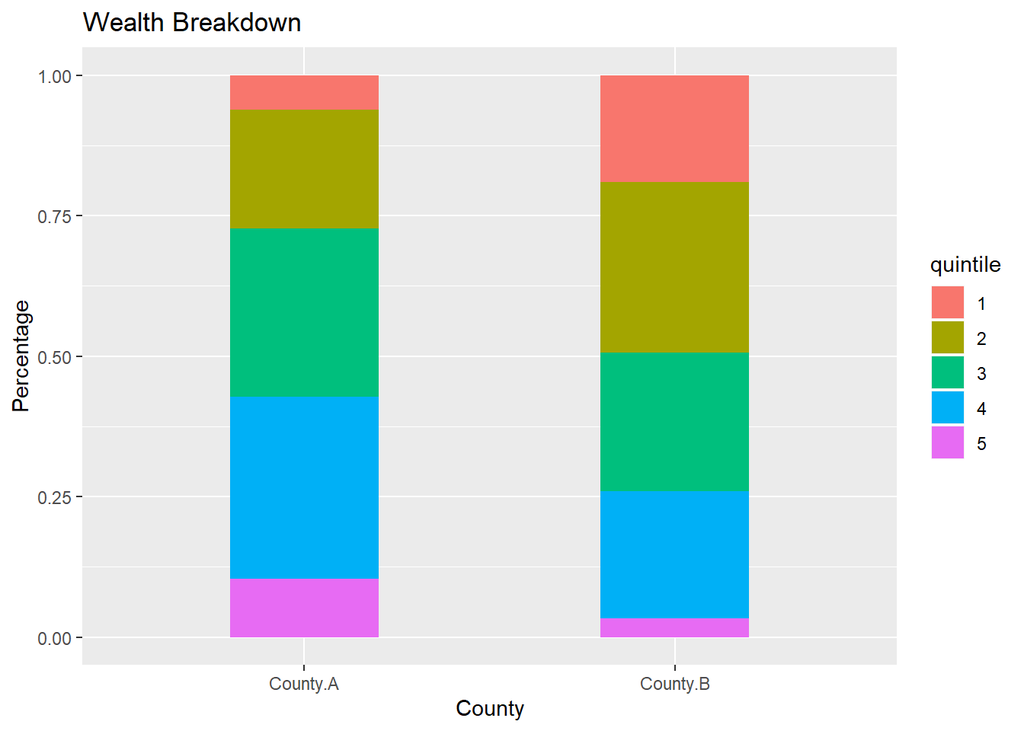

```r
ggplot(newdata, aes(County)) + geom_bar(aes(fill = quintile), position = "fill",width = 0.4) +
  xlab("County") +
  ylab("Percentage") +
  ggtitle("Wealth Breakdown")
```